# Risk Factor Analysis

## Outcome Variable

**Outcome Variable:** ever_wasted

## Predictor Variables

**Intervention Variable:** birthwt

**Adjustment Set:**

- arm
- sex
- W_mage
- meducyrs
- feducyrs
- vagbrth
- single
- brthmon
- W_parity
- delta_W_mage
- delta_meducyrs
- delta_feducyrs
- delta_vagbrth
- delta_single
- delta_brthmon
- delta_W_parity

## Stratifying Variables

The analysis was stratified on these variable(s):

- agecat
- studyid
- country

## Data Summary

| agecat | studyid | country | birthwt | ever_wasted | n_cell | n |
| --- | --- | --- | --- | --- | --- | --- |
| 0-24 months (no birth wast) | CMC-V-BCS-2002 | INDIA | Normal or high birthweight | 0 | 181 | 361 |
| 0-24 months (no birth wast) | CMC-V-BCS-2002 | INDIA | Normal or high birthweight | 1 | 140 | 361 |
| 0-24 months (no birth wast) | CMC-V-BCS-2002 | INDIA | Low birthweight | 0 | 17 | 361 |
| 0-24 months (no birth wast) | CMC-V-BCS-2002 | INDIA | Low birthweight | 1 | 23 | 361 |
| 0-24 months (no birth wast) | CMIN | BANGLADESH | Normal or high birthweight | 0 | 10 | 17 |
| 0-24 months (no birth wast) | CMIN | BANGLADESH | Normal or high birthweight | 1 | 3 | 17 |
| 0-24 months (no birth wast) | CMIN | BANGLADESH | Low birthweight | 0 | 2 | 17 |
| 0-24 months (no birth wast) | CMIN | BANGLADESH | Low birthweight | 1 | 2 | 17 |
| 0-24 months (no birth wast) | COHORTS | GUATEMALA | Normal or high birthweight | 0 | 740 | 917 |
| 0-24 months (no birth wast) | COHORTS | GUATEMALA | Normal or high birthweight | 1 | 98 | 917 |
| 0-24 months (no birth wast) | COHORTS | GUATEMALA | Low birthweight | 0 | 62 | 917 |
| 0-24 months (no birth wast) | COHORTS | GUATEMALA | Low birthweight | 1 | 17 | 917 |
| 0-24 months (no birth wast) | COHORTS | INDIA | Normal or high birthweight | 0 | 4360 | 6524 |
| 0-24 months (no birth wast) | COHORTS | INDIA | Normal or high birthweight | 1 | 953 | 6524 |
| 0-24 months (no birth wast) | COHORTS | INDIA | Low birthweight | 0 | 911 | 6524 |
| 0-24 months (no birth wast) | COHORTS | INDIA | Low birthweight | 1 | 300 | 6524 |
| 0-24 months (no birth wast) | COHORTS | PHILIPPINES | Normal or high birthweight | 0 | 1923 | 2975 |
| 0-24 months (no birth wast) | COHORTS | PHILIPPINES | Normal or high birthweight | 1 | 781 | 2975 |
| 0-24 months (no birth wast) | COHORTS | PHILIPPINES | Low birthweight | 0 | 148 | 2975 |
| 0-24 months (no birth wast) | COHORTS | PHILIPPINES | Low birthweight | 1 | 123 | 2975 |
| 0-24 months (no birth wast) | CONTENT | PERU | Normal or high birthweight | 0 | 2 | 2 |
| 0-24 months (no birth wast) | CONTENT | PERU | Normal or high birthweight | 1 | 0 | 2 |
| 0-24 months (no birth wast) | CONTENT | PERU | Low birthweight | 0 | 0 | 2 |
| 0-24 months (no birth wast) | CONTENT | PERU | Low birthweight | 1 | 0 | 2 |
| 0-24 months (no birth wast) | EE | PAKISTAN | Normal or high birthweight | 0 | 124 | 376 |
| 0-24 months (no birth wast) | EE | PAKISTAN | Normal or high birthweight | 1 | 119 | 376 |
| 0-24 months (no birth wast) | EE | PAKISTAN | Low birthweight | 0 | 50 | 376 |
| 0-24 months (no birth wast) | EE | PAKISTAN | Low birthweight | 1 | 83 | 376 |
| 0-24 months (no birth wast) | GMS-Nepal | NEPAL | Normal or high birthweight | 0 | 254 | 659 |
| 0-24 months (no birth wast) | GMS-Nepal | NEPAL | Normal or high birthweight | 1 | 215 | 659 |

[output cut: 294 more lines]

The following strata were considered:

- agecat: 0-24 months (no birth wast), studyid: CMC-V-BCS-2002, country: INDIA
- agecat: 0-24 months (no birth wast), studyid: CMIN, country: BANGLADESH
- agecat: 0-24 months (no birth wast), studyid: COHORTS, country: GUATEMALA
- agecat: 0-24 months (no birth wast), studyid: COHORTS, country: INDIA
- agecat: 0-24 months (no birth wast), studyid: COHORTS, country: PHILIPPINES
- agecat: 0-24 months (no birth wast), studyid: CONTENT, country: PERU
- agecat: 0-24 months (no birth wast), studyid: EE, country: PAKISTAN
- agecat: 0-24 months (no birth wast), studyid: GMS-Nepal, country: NEPAL
- agecat: 0-24 months (no birth wast), studyid: IRC, country: INDIA
- agecat: 0-24 months (no birth wast), studyid: JiVitA-3, country: BANGLADESH
- agecat: 0-24 months (no birth wast), studyid: JiVitA-4, country: BANGLADESH
- agecat: 0-24 months (no birth wast), studyid: Keneba, country: GAMBIA
- agecat: 0-24 months (no birth wast), studyid: MAL-ED, country: BANGLADESH
- agecat: 0-24 months (no birth wast), studyid: MAL-ED, country: BRAZIL
- agecat: 0-24 months (no birth wast), studyid: MAL-ED, country: INDIA
- agecat: 0-24 months (no birth wast), studyid: MAL-ED, country: NEPAL
- agecat: 0-24 months (no birth wast), studyid: MAL-ED, country: PERU
- agecat: 0-24 months (no birth wast), studyid: MAL-ED, country: SOUTH AFRICA
- agecat: 0-24 months (no birth wast), studyid: MAL-ED, country: TANZANIA, UNITED REPUBLIC OF
- agecat: 0-24 months (no birth wast), studyid: NIH-Birth, country: BANGLADESH
- agecat: 0-24 months (no birth wast), studyid: NIH-Crypto, country: BANGLADESH
- agecat: 0-24 months (no birth wast), studyid: PROBIT, country: BELARUS
- agecat: 0-24 months (no birth wast), studyid: PROVIDE, country: BANGLADESH
- agecat: 0-24 months (no birth wast), studyid: ResPak, country: PAKISTAN
- agecat: 0-24 months (no birth wast), studyid: SAS-CompFeed, country: INDIA
- agecat: 0-24 months (no birth wast), studyid: TanzaniaChild2, country: TANZANIA, UNITED REPUBLIC OF
- agecat: 0-24 months (no birth wast), studyid: ZVITAMBO, country: ZIMBABWE
- agecat: 0-6 months (no birth wast), studyid: CMC-V-BCS-2002, country: INDIA
- agecat: 0-6 months (no birth wast), studyid: CMIN, country: BANGLADESH
- agecat: 0-6 months (no birth wast), studyid: COHORTS, country: GUATEMALA
- agecat: 0-6 months (no birth wast), studyid: COHORTS, country: INDIA
- agecat: 0-6 months (no birth wast), studyid: COHORTS, country: PHILIPPINES
- agecat: 0-6 months (no birth wast), studyid: CONTENT, country: PERU
- agecat: 0-6 months (no birth wast), studyid: EE, country: PAKISTAN
- agecat: 0-6 months (no birth wast), studyid: GMS-Nepal, country: NEPAL
- agecat: 0-6 months (no birth wast), studyid: IRC, country: INDIA
- agecat: 0-6 months (no birth wast), studyid: JiVitA-3, country: BANGLADESH
- agecat: 0-6 months (no birth wast), studyid: JiVitA-4, country: BANGLADESH
- agecat: 0-6 months (no birth wast), studyid: Keneba, country: GAMBIA
- agecat: 0-6 months (no birth wast), studyid: MAL-ED, country: BANGLADESH
- agecat: 0-6 months (no birth wast), studyid: MAL-ED, country: BRAZIL
- agecat: 0-6 months (no birth wast), studyid: MAL-ED, country: INDIA
- agecat: 0-6 months (no birth wast), studyid: MAL-ED, country: NEPAL
- agecat: 0-6 months (no birth wast), studyid: MAL-ED, country: PERU
- agecat: 0-6 months (no birth wast), studyid: MAL-ED, country: SOUTH AFRICA
- agecat: 0-6 months (no birth wast), studyid: MAL-ED, country: TANZANIA, UNITED REPUBLIC OF
- agecat: 0-6 months (no birth wast), studyid: NIH-Birth, country: BANGLADESH
- agecat: 0-6 months (no birth wast), studyid: NIH-Crypto, country: BANGLADESH
- agecat: 0-6 months (no birth wast), studyid: PROBIT, country: BELARUS
- agecat: 0-6 months (no birth wast), studyid: PROVIDE, country: BANGLADESH
- agecat: 0-6 months (no birth wast), studyid: ResPak, country: PAKISTAN
- agecat: 0-6 months (no birth wast), studyid: SAS-CompFeed, country: INDIA
- agecat: 0-6 months (no birth wast), studyid: TanzaniaChild2, country: TANZANIA, UNITED REPUBLIC OF
- agecat: 0-6 months (no birth wast), studyid: ZVITAMBO, country: ZIMBABWE
- agecat: 6-24 months, studyid: CMC-V-BCS-2002, country: INDIA
- agecat: 6-24 months, studyid: CMIN, country: BANGLADESH
- agecat: 6-24 months, studyid: COHORTS, country: GUATEMALA
- agecat: 6-24 months, studyid: COHORTS, country: INDIA
- agecat: 6-24 months, studyid: COHORTS, country: PHILIPPINES
- agecat: 6-24 months, studyid: CONTENT, country: PERU
- agecat: 6-24 months, studyid: EE, country: PAKISTAN
- agecat: 6-24 months, studyid: GMS-Nepal, country: NEPAL
- agecat: 6-24 months, studyid: IRC, country: INDIA
- agecat: 6-24 months, studyid: JiVitA-3, country: BANGLADESH
- agecat: 6-24 months, studyid: JiVitA-4, country: BANGLADESH
- agecat: 6-24 months, studyid: Keneba, country: GAMBIA
- agecat: 6-24 months, studyid: MAL-ED, country: BANGLADESH
- agecat: 6-24 months, studyid: MAL-ED, country: BRAZIL
- agecat: 6-24 months, studyid: MAL-ED, country: INDIA
- agecat: 6-24 months, studyid: MAL-ED, country: NEPAL
- agecat: 6-24 months, studyid: MAL-ED, country: PERU
- agecat: 6-24 months, studyid: MAL-ED, country: SOUTH AFRICA
- agecat: 6-24 months, studyid: MAL-ED, country: TANZANIA, UNITED REPUBLIC OF
- agecat: 6-24 months, studyid: NIH-Birth, country: BANGLADESH
- agecat: 6-24 months, studyid: NIH-Crypto, country: BANGLADESH
- agecat: 6-24 months, studyid: PROBIT, country: BELARUS
- agecat: 6-24 months, studyid: PROVIDE, country: BANGLADESH
- agecat: 6-24 months, studyid: ResPak, country: PAKISTAN
- agecat: 6-24 months, studyid: SAS-CompFeed, country: INDIA
- agecat: 6-24 months, studyid: TanzaniaChild2, country: TANZANIA, UNITED REPUBLIC OF
- agecat: 6-24 months, studyid: ZVITAMBO, country: ZIMBABWE

### Dropped Strata

Some strata were dropped due to rare outcomes:

- agecat: 0-24 months (no birth wast), studyid: CMIN, country: BANGLADESH
- agecat: 0-24 months (no birth wast), studyid: CONTENT, country: PERU
- agecat: 0-24 months (no birth wast), studyid: MAL-ED, country: BRAZIL
- agecat: 0-24 months (no birth wast), studyid: MAL-ED, country: TANZANIA, UNITED REPUBLIC OF
- agecat: 0-24 months (no birth wast), studyid: PROBIT, country: BELARUS
- agecat: 0-24 months (no birth wast), studyid: ResPak, country: PAKISTAN
- agecat: 0-6 months (no birth wast), studyid: CMIN, country: BANGLADESH
- agecat: 0-6 months (no birth wast), studyid: COHORTS, country: GUATEMALA
- agecat: 0-6 months (no birth wast), studyid: CONTENT, country: PERU
- agecat: 0-6 months (no birth wast), studyid: MAL-ED, country: BANGLADESH
- agecat: 0-6 months (no birth wast), studyid: MAL-ED, country: BRAZIL
- agecat: 0-6 months (no birth wast), studyid: MAL-ED, country: INDIA
- agecat: 0-6 months (no birth wast), studyid: MAL-ED, country: NEPAL
- agecat: 0-6 months (no birth wast), studyid: MAL-ED, country: PERU
- agecat: 0-6 months (no birth wast), studyid: MAL-ED, country: SOUTH AFRICA
- agecat: 0-6 months (no birth wast), studyid: MAL-ED, country: TANZANIA, UNITED REPUBLIC OF
- agecat: 0-6 months (no birth wast), studyid: NIH-Crypto, country: BANGLADESH
- agecat: 0-6 months (no birth wast), studyid: PROBIT, country: BELARUS
- agecat: 0-6 months (no birth wast), studyid: ResPak, country: PAKISTAN
- agecat: 6-24 months, studyid: CMIN, country: BANGLADESH
- agecat: 6-24 months, studyid: CONTENT, country: PERU
- agecat: 6-24 months, studyid: MAL-ED, country: BRAZIL
- agecat: 6-24 months, studyid: MAL-ED, country: PERU
- agecat: 6-24 months, studyid: MAL-ED, country: TANZANIA, UNITED REPUBLIC OF
- agecat: 6-24 months, studyid: PROBIT, country: BELARUS
- agecat: 6-24 months, studyid: ResPak, country: PAKISTAN

## Methods Detail

We’re interested in the causal parameters $E[Y_a]$ for all values of $a \in \mathcal{A}$. These parameters represent the mean outcome if, possibly contrary to fact, we intervened to set all units to have $A=a$. Under the randomization and positivity assumptions, these are identified by the statistical parameters $\psi_a=E_W[E_{Y|A,W}(Y|A=a,W)]$. In addition, we’re interested in the mean of $Y$, $E[Y]$ under no intervention (the observed mean). We will estimate these parameters by using SuperLearner to fit the relevant likelihood factors – $E_{Y|A,W}(Y|A=a,W)$ and $p(A=a|W)$, and then updating our likelihood fit using a joint TMLE.

For unadjusted analyses ($W=\{\}$), initial likelihoods were estimated using Lrnr_glm to estimate the simple $E(Y|A)$ and Lrnr_mean to estimate $p(A)$. For adjusted analyses, a small library containing Lrnr_glmnet, Lrnr_xgboost, and Lrnr_mean was used.

Having estimated these parameters, we will then use the delta method to estimate relative risks and attributable risks relative to a prespecified baseline level of $A$.

# Results Detail

## Results Plots

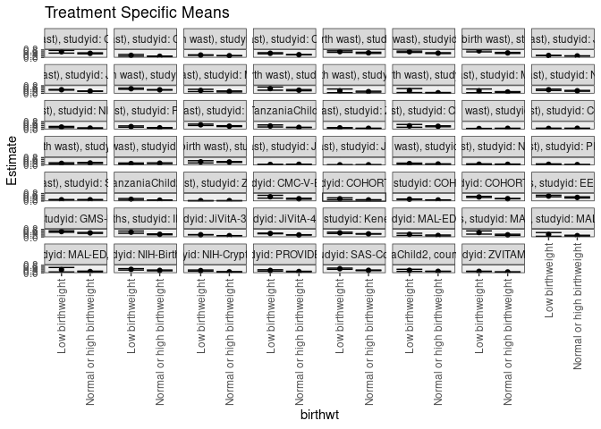

[figure not shown]

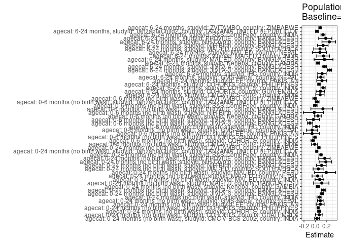

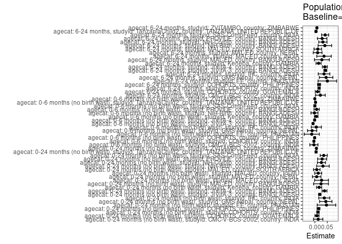

## Results Table

### Parameter: TSM

| agecat | studyid | country | intervention_level | baseline_level | estimate | ci_lower | ci_upper |
| --- | --- | --- | --- | --- | --- | --- | --- |
| 0-24 months (no birth wast) | CMC-V-BCS-2002 | INDIA | Normal or high birthweight | NA | 0.4380768 | 0.3837075 | 0.4924460 |
| 0-24 months (no birth wast) | CMC-V-BCS-2002 | INDIA | Low birthweight | NA | 0.6088581 | 0.4605781 | 0.7571380 |
| 0-24 months (no birth wast) | COHORTS | GUATEMALA | Normal or high birthweight | NA | 0.1168713 | 0.0950851 | 0.1386576 |
| 0-24 months (no birth wast) | COHORTS | GUATEMALA | Low birthweight | NA | 0.2187032 | 0.1240060 | 0.3134004 |
| 0-24 months (no birth wast) | COHORTS | INDIA | Normal or high birthweight | NA | 0.1795304 | 0.1691947 | 0.1898660 |
| 0-24 months (no birth wast) | COHORTS | INDIA | Low birthweight | NA | 0.2494601 | 0.2245736 | 0.2743467 |
| 0-24 months (no birth wast) | COHORTS | PHILIPPINES | Normal or high birthweight | NA | 0.2892516 | 0.2721580 | 0.3063452 |
| 0-24 months (no birth wast) | COHORTS | PHILIPPINES | Low birthweight | NA | 0.4439689 | 0.3854322 | 0.5025055 |
| 0-24 months (no birth wast) | EE | PAKISTAN | Normal or high birthweight | NA | 0.4906201 | 0.4274259 | 0.5538142 |
| 0-24 months (no birth wast) | EE | PAKISTAN | Low birthweight | NA | 0.6247464 | 0.5420298 | 0.7074630 |
| 0-24 months (no birth wast) | GMS-Nepal | NEPAL | Normal or high birthweight | NA | 0.4568056 | 0.4114382 | 0.5021729 |
| 0-24 months (no birth wast) | GMS-Nepal | NEPAL | Low birthweight | NA | 0.6075261 | 0.5358319 | 0.6792202 |
| 0-24 months (no birth wast) | IRC | INDIA | Normal or high birthweight | NA | 0.4833173 | 0.4296852 | 0.5369494 |
| 0-24 months (no birth wast) | IRC | INDIA | Low birthweight | NA | 0.7078726 | 0.5982291 | 0.8175161 |
| 0-24 months (no birth wast) | JiVitA-3 | BANGLADESH | Normal or high birthweight | NA | 0.1556647 | 0.1478960 | 0.1634334 |
| 0-24 months (no birth wast) | JiVitA-3 | BANGLADESH | Low birthweight | NA | 0.2050095 | 0.1958615 | 0.2141575 |
| 0-24 months (no birth wast) | JiVitA-4 | BANGLADESH | Normal or high birthweight | NA | 0.2286292 | 0.2111599 | 0.2460985 |
| 0-24 months (no birth wast) | JiVitA-4 | BANGLADESH | Low birthweight | NA | 0.3781023 | 0.3448891 | 0.4113155 |
| 0-24 months (no birth wast) | Keneba | GAMBIA | Normal or high birthweight | NA | 0.3702540 | 0.3441072 | 0.3964007 |
| 0-24 months (no birth wast) | Keneba | GAMBIA | Low birthweight | NA | 0.4924812 | 0.4250393 | 0.5599232 |
| 0-24 months (no birth wast) | MAL-ED | BANGLADESH | Normal or high birthweight | NA | 0.1943874 | 0.1403008 | 0.2484740 |
| 0-24 months (no birth wast) | MAL-ED | BANGLADESH | Low birthweight | NA | 0.3038219 | 0.1805917 | 0.4270521 |
| 0-24 months (no birth wast) | MAL-ED | INDIA | Normal or high birthweight | NA | 0.3331962 | 0.2680508 | 0.3983417 |
| 0-24 months (no birth wast) | MAL-ED | INDIA | Low birthweight | NA | 0.5037104 | 0.3309933 | 0.6764274 |
| 0-24 months (no birth wast) | MAL-ED | NEPAL | Normal or high birthweight | NA | 0.1737089 | 0.1227202 | 0.2246976 |
| 0-24 months (no birth wast) | MAL-ED | NEPAL | Low birthweight | NA | 0.2631579 | 0.0647291 | 0.4615867 |
| 0-24 months (no birth wast) | MAL-ED | PERU | Normal or high birthweight | NA | 0.0567376 | 0.0296916 | 0.0837836 |
| 0-24 months (no birth wast) | MAL-ED | PERU | Low birthweight | NA | 0.2941176 | 0.0771586 | 0.5110767 |
| 0-24 months (no birth wast) | MAL-ED | SOUTH AFRICA | Normal or high birthweight | NA | 0.1393728 | 0.0992386 | 0.1795070 |
| 0-24 months (no birth wast) | MAL-ED | SOUTH AFRICA | Low birthweight | NA | 0.2631579 | 0.0648329 | 0.4614829 |

[output cut: 80 more lines]

### Parameter: E(Y)

| agecat | studyid | country | intervention_level | baseline_level | estimate | ci_lower | ci_upper |
| --- | --- | --- | --- | --- | --- | --- | --- |
| 0-24 months (no birth wast) | CMC-V-BCS-2002 | INDIA | NA | NA | 0.4515235 | 0.4001173 | 0.5029298 |
| 0-24 months (no birth wast) | COHORTS | GUATEMALA | NA | NA | 0.1254089 | 0.1039619 | 0.1468560 |
| 0-24 months (no birth wast) | COHORTS | INDIA | NA | NA | 0.1920601 | 0.1825006 | 0.2016195 |
| 0-24 months (no birth wast) | COHORTS | PHILIPPINES | NA | NA | 0.3038655 | 0.2873358 | 0.3203952 |
| 0-24 months (no birth wast) | EE | PAKISTAN | NA | NA | 0.5372340 | 0.4867685 | 0.5876996 |
| 0-24 months (no birth wast) | GMS-Nepal | NEPAL | NA | NA | 0.5007587 | 0.4625551 | 0.5389624 |
| 0-24 months (no birth wast) | IRC | INDIA | NA | NA | 0.5210918 | 0.4722583 | 0.5699254 |
| 0-24 months (no birth wast) | JiVitA-3 | BANGLADESH | NA | NA | 0.1755073 | 0.1694892 | 0.1815253 |
| 0-24 months (no birth wast) | JiVitA-4 | BANGLADESH | NA | NA | 0.2674393 | 0.2524050 | 0.2824735 |
| 0-24 months (no birth wast) | Keneba | GAMBIA | NA | NA | 0.3874755 | 0.3630804 | 0.4118706 |
| 0-24 months (no birth wast) | MAL-ED | BANGLADESH | NA | NA | 0.2192308 | 0.1688447 | 0.2696168 |
| 0-24 months (no birth wast) | MAL-ED | INDIA | NA | NA | 0.3601695 | 0.2987933 | 0.4215457 |
| 0-24 months (no birth wast) | MAL-ED | NEPAL | NA | NA | 0.1810345 | 0.1313803 | 0.2306886 |
| 0-24 months (no birth wast) | MAL-ED | PERU | NA | NA | 0.0702341 | 0.0412206 | 0.0992477 |
| 0-24 months (no birth wast) | MAL-ED | SOUTH AFRICA | NA | NA | 0.1470588 | 0.1073119 | 0.1868057 |
| 0-24 months (no birth wast) | NIH-Birth | BANGLADESH | NA | NA | 0.2977625 | 0.2605481 | 0.3349769 |
| 0-24 months (no birth wast) | NIH-Crypto | BANGLADESH | NA | NA | 0.1432361 | 0.1182149 | 0.1682572 |
| 0-24 months (no birth wast) | PROVIDE | BANGLADESH | NA | NA | 0.1775837 | 0.1489858 | 0.2061816 |
| 0-24 months (no birth wast) | SAS-CompFeed | INDIA | NA | NA | 0.3626005 | 0.3118807 | 0.4133204 |
| 0-24 months (no birth wast) | TanzaniaChild2 | TANZANIA, UNITED REPUBLIC OF | NA | NA | 0.1979652 | 0.1818822 | 0.2140482 |
| 0-24 months (no birth wast) | ZVITAMBO | ZIMBABWE | NA | NA | 0.1019642 | 0.0968771 | 0.1070514 |
| 0-6 months (no birth wast) | CMC-V-BCS-2002 | INDIA | NA | NA | 0.3081395 | 0.2592761 | 0.3570030 |
| 0-6 months (no birth wast) | COHORTS | INDIA | NA | NA | 0.0882207 | 0.0810753 | 0.0953662 |
| 0-6 months (no birth wast) | COHORTS | PHILIPPINES | NA | NA | 0.0954638 | 0.0848652 | 0.1060624 |
| 0-6 months (no birth wast) | EE | PAKISTAN | NA | NA | 0.2139037 | 0.1722896 | 0.2555179 |
| 0-6 months (no birth wast) | GMS-Nepal | NEPAL | NA | NA | 0.1918877 | 0.1613794 | 0.2223959 |
| 0-6 months (no birth wast) | IRC | INDIA | NA | NA | 0.3385417 | 0.2911496 | 0.3859338 |
| 0-6 months (no birth wast) | JiVitA-3 | BANGLADESH | NA | NA | 0.0754015 | 0.0712481 | 0.0795550 |
| 0-6 months (no birth wast) | JiVitA-4 | BANGLADESH | NA | NA | 0.0288198 | 0.0235259 | 0.0341136 |
| 0-6 months (no birth wast) | Keneba | GAMBIA | NA | NA | 0.1191573 | 0.1028598 | 0.1354549 |
| 0-6 months (no birth wast) | NIH-Birth | BANGLADESH | NA | NA | 0.0797872 | 0.0574049 | 0.1021695 |
| 0-6 months (no birth wast) | PROVIDE | BANGLADESH | NA | NA | 0.0541728 | 0.0371844 | 0.0711612 |
| 0-6 months (no birth wast) | SAS-CompFeed | INDIA | NA | NA | 0.1262799 | 0.0958566 | 0.1567031 |
| 0-6 months (no birth wast) | TanzaniaChild2 | TANZANIA, UNITED REPUBLIC OF | NA | NA | 0.0850702 | 0.0737905 | 0.0963499 |
| 0-6 months (no birth wast) | ZVITAMBO | ZIMBABWE | NA | NA | 0.0320984 | 0.0291065 | 0.0350903 |
| 6-24 months | CMC-V-BCS-2002 | INDIA | NA | NA | 0.2657534 | 0.2203741 | 0.3111327 |
| 6-24 months | COHORTS | GUATEMALA | NA | NA | 0.1233374 | 0.1009129 | 0.1457618 |
| 6-24 months | COHORTS | INDIA | NA | NA | 0.1241467 | 0.1160028 | 0.1322905 |
| 6-24 months | COHORTS | PHILIPPINES | NA | NA | 0.2668113 | 0.2503255 | 0.2832971 |
| 6-24 months | EE | PAKISTAN | NA | NA | 0.4316354 | 0.3813029 | 0.4819679 |
| 6-24 months | GMS-Nepal | NEPAL | NA | NA | 0.4719864 | 0.4316361 | 0.5123367 |
| 6-24 months | IRC | INDIA | NA | NA | 0.3118812 | 0.2666517 | 0.3571107 |
| 6-24 months | JiVitA-3 | BANGLADESH | NA | NA | 0.1678827 | 0.1611001 | 0.1746653 |
| 6-24 months | JiVitA-4 | BANGLADESH | NA | NA | 0.2520560 | 0.2372444 | 0.2668676 |
| 6-24 months | Keneba | GAMBIA | NA | NA | 0.3374067 | 0.3132523 | 0.3615610 |
| 6-24 months | MAL-ED | BANGLADESH | NA | NA | 0.1764706 | 0.1279362 | 0.2250050 |
| 6-24 months | MAL-ED | INDIA | NA | NA | 0.2566372 | 0.1995660 | 0.3137084 |
| 6-24 months | MAL-ED | NEPAL | NA | NA | 0.1403509 | 0.0951649 | 0.1855368 |
| 6-24 months | MAL-ED | SOUTH AFRICA | NA | NA | 0.1434109 | 0.1005601 | 0.1862616 |
| 6-24 months | NIH-Birth | BANGLADESH | NA | NA | 0.2950192 | 0.2558591 | 0.3341792 |
| 6-24 months | NIH-Crypto | BANGLADESH | NA | NA | 0.1315068 | 0.1069744 | 0.1560393 |
| 6-24 months | PROVIDE | BANGLADESH | NA | NA | 0.1609756 | 0.1319065 | 0.1900447 |
| 6-24 months | SAS-CompFeed | INDIA | NA | NA | 0.3067440 | 0.2633529 | 0.3501352 |
| 6-24 months | TanzaniaChild2 | TANZANIA, UNITED REPUBLIC OF | NA | NA | 0.1596597 | 0.1435945 | 0.1757248 |
| 6-24 months | ZVITAMBO | ZIMBABWE | NA | NA | 0.0957328 | 0.0901784 | 0.1012872 |

### Parameter: RR

| agecat | studyid | country | intervention_level | baseline_level | estimate | ci_lower | ci_upper |
| --- | --- | --- | --- | --- | --- | --- | --- |
| 0-24 months (no birth wast) | CMC-V-BCS-2002 | INDIA | Normal or high birthweight | Normal or high birthweight | 1.0000000 | 1.0000000 | 1.0000000 |
| 0-24 months (no birth wast) | CMC-V-BCS-2002 | INDIA | Low birthweight | Normal or high birthweight | 1.3898433 | 1.0573674 | 1.8268623 |
| 0-24 months (no birth wast) | COHORTS | GUATEMALA | Normal or high birthweight | Normal or high birthweight | 1.0000000 | 1.0000000 | 1.0000000 |
| 0-24 months (no birth wast) | COHORTS | GUATEMALA | Low birthweight | Normal or high birthweight | 1.8713165 | 1.1680231 | 2.9980790 |
| 0-24 months (no birth wast) | COHORTS | INDIA | Normal or high birthweight | Normal or high birthweight | 1.0000000 | 1.0000000 | 1.0000000 |
| 0-24 months (no birth wast) | COHORTS | INDIA | Low birthweight | Normal or high birthweight | 1.3895150 | 1.2386901 | 1.5587046 |
| 0-24 months (no birth wast) | COHORTS | PHILIPPINES | Normal or high birthweight | Normal or high birthweight | 1.0000000 | 1.0000000 | 1.0000000 |
| 0-24 months (no birth wast) | COHORTS | PHILIPPINES | Low birthweight | Normal or high birthweight | 1.5348883 | 1.3289817 | 1.7726971 |
| 0-24 months (no birth wast) | EE | PAKISTAN | Normal or high birthweight | Normal or high birthweight | 1.0000000 | 1.0000000 | 1.0000000 |
| 0-24 months (no birth wast) | EE | PAKISTAN | Low birthweight | Normal or high birthweight | 1.2733812 | 1.0587625 | 1.5315047 |
| 0-24 months (no birth wast) | GMS-Nepal | NEPAL | Normal or high birthweight | Normal or high birthweight | 1.0000000 | 1.0000000 | 1.0000000 |
| 0-24 months (no birth wast) | GMS-Nepal | NEPAL | Low birthweight | Normal or high birthweight | 1.3299445 | 1.1398631 | 1.5517236 |
| 0-24 months (no birth wast) | IRC | INDIA | Normal or high birthweight | Normal or high birthweight | 1.0000000 | 1.0000000 | 1.0000000 |
| 0-24 months (no birth wast) | IRC | INDIA | Low birthweight | Normal or high birthweight | 1.4646128 | 1.2101196 | 1.7726269 |
| 0-24 months (no birth wast) | JiVitA-3 | BANGLADESH | Normal or high birthweight | Normal or high birthweight | 1.0000000 | 1.0000000 | 1.0000000 |
| 0-24 months (no birth wast) | JiVitA-3 | BANGLADESH | Low birthweight | Normal or high birthweight | 1.3169941 | 1.2341051 | 1.4054504 |
| 0-24 months (no birth wast) | JiVitA-4 | BANGLADESH | Normal or high birthweight | Normal or high birthweight | 1.0000000 | 1.0000000 | 1.0000000 |
| 0-24 months (no birth wast) | JiVitA-4 | BANGLADESH | Low birthweight | Normal or high birthweight | 1.6537796 | 1.4703526 | 1.8600892 |
| 0-24 months (no birth wast) | Keneba | GAMBIA | Normal or high birthweight | Normal or high birthweight | 1.0000000 | 1.0000000 | 1.0000000 |
| 0-24 months (no birth wast) | Keneba | GAMBIA | Low birthweight | Normal or high birthweight | 1.3301174 | 1.1407943 | 1.5508601 |
| 0-24 months (no birth wast) | MAL-ED | BANGLADESH | Normal or high birthweight | Normal or high birthweight | 1.0000000 | 1.0000000 | 1.0000000 |
| 0-24 months (no birth wast) | MAL-ED | BANGLADESH | Low birthweight | Normal or high birthweight | 1.5629714 | 0.9546511 | 2.5589237 |
| 0-24 months (no birth wast) | MAL-ED | INDIA | Normal or high birthweight | Normal or high birthweight | 1.0000000 | 1.0000000 | 1.0000000 |
| 0-24 months (no birth wast) | MAL-ED | INDIA | Low birthweight | Normal or high birthweight | 1.5117529 | 1.0172766 | 2.2465836 |
| 0-24 months (no birth wast) | MAL-ED | NEPAL | Normal or high birthweight | Normal or high birthweight | 1.0000000 | 1.0000000 | 1.0000000 |
| 0-24 months (no birth wast) | MAL-ED | NEPAL | Low birthweight | Normal or high birthweight | 1.5149360 | 0.6745061 | 3.4025355 |
| 0-24 months (no birth wast) | MAL-ED | PERU | Normal or high birthweight | Normal or high birthweight | 1.0000000 | 1.0000000 | 1.0000000 |
| 0-24 months (no birth wast) | MAL-ED | PERU | Low birthweight | Normal or high birthweight | 5.1838235 | 2.1538670 | 12.4761774 |
| 0-24 months (no birth wast) | MAL-ED | SOUTH AFRICA | Normal or high birthweight | Normal or high birthweight | 1.0000000 | 1.0000000 | 1.0000000 |
| 0-24 months (no birth wast) | MAL-ED | SOUTH AFRICA | Low birthweight | Normal or high birthweight | 1.8881579 | 0.8426742 | 4.2307456 |

[output cut: 80 more lines]

### Parameter: PAR

| agecat | studyid | country | intervention_level | baseline_level | estimate | ci_lower | ci_upper |
| --- | --- | --- | --- | --- | --- | --- | --- |
| 0-24 months (no birth wast) | CMC-V-BCS-2002 | INDIA | Normal or high birthweight | NA | 0.0134468 | -0.0053811 | 0.0322747 |
| 0-24 months (no birth wast) | COHORTS | GUATEMALA | Normal or high birthweight | NA | 0.0085376 | 0.0002989 | 0.0167764 |
| 0-24 months (no birth wast) | COHORTS | INDIA | Normal or high birthweight | NA | 0.0125297 | 0.0075795 | 0.0174799 |
| 0-24 months (no birth wast) | COHORTS | PHILIPPINES | Normal or high birthweight | NA | 0.0146140 | 0.0088271 | 0.0204008 |
| 0-24 months (no birth wast) | EE | PAKISTAN | Normal or high birthweight | NA | 0.0466140 | 0.0093451 | 0.0838828 |
| 0-24 months (no birth wast) | GMS-Nepal | NEPAL | Normal or high birthweight | NA | 0.0439532 | 0.0190803 | 0.0688260 |
| 0-24 months (no birth wast) | IRC | INDIA | Normal or high birthweight | NA | 0.0377746 | 0.0156697 | 0.0598794 |
| 0-24 months (no birth wast) | JiVitA-3 | BANGLADESH | Normal or high birthweight | NA | 0.0198426 | 0.0149745 | 0.0247106 |
| 0-24 months (no birth wast) | JiVitA-4 | BANGLADESH | Normal or high birthweight | NA | 0.0388101 | 0.0289579 | 0.0486623 |
| 0-24 months (no birth wast) | Keneba | GAMBIA | Normal or high birthweight | NA | 0.0172216 | 0.0068685 | 0.0275747 |
| 0-24 months (no birth wast) | MAL-ED | BANGLADESH | Normal or high birthweight | NA | 0.0248434 | -0.0049443 | 0.0546311 |
| 0-24 months (no birth wast) | MAL-ED | INDIA | Normal or high birthweight | NA | 0.0269733 | -0.0008036 | 0.0547502 |
| 0-24 months (no birth wast) | MAL-ED | NEPAL | Normal or high birthweight | NA | 0.0073256 | -0.0097485 | 0.0243997 |
| 0-24 months (no birth wast) | MAL-ED | PERU | Normal or high birthweight | NA | 0.0134965 | -0.0004132 | 0.0274062 |
| 0-24 months (no birth wast) | MAL-ED | SOUTH AFRICA | Normal or high birthweight | NA | 0.0076860 | -0.0053175 | 0.0206895 |
| 0-24 months (no birth wast) | NIH-Birth | BANGLADESH | Normal or high birthweight | NA | 0.0325227 | 0.0073625 | 0.0576829 |
| 0-24 months (no birth wast) | NIH-Crypto | BANGLADESH | Normal or high birthweight | NA | 0.0263100 | 0.0101447 | 0.0424753 |
| 0-24 months (no birth wast) | PROVIDE | BANGLADESH | Normal or high birthweight | NA | 0.0292233 | 0.0111136 | 0.0473330 |
| 0-24 months (no birth wast) | SAS-CompFeed | INDIA | Normal or high birthweight | NA | 0.0356704 | 0.0214579 | 0.0498828 |
| 0-24 months (no birth wast) | TanzaniaChild2 | TANZANIA, UNITED REPUBLIC OF | Normal or high birthweight | NA | 0.0050043 | 0.0012726 | 0.0087361 |
| 0-24 months (no birth wast) | ZVITAMBO | ZIMBABWE | Normal or high birthweight | NA | 0.0063129 | 0.0041083 | 0.0085176 |
| 0-6 months (no birth wast) | CMC-V-BCS-2002 | INDIA | Normal or high birthweight | NA | -0.0038271 | -0.0201838 | 0.0125295 |
| 0-6 months (no birth wast) | COHORTS | INDIA | Normal or high birthweight | NA | -0.0038699 | -0.0068239 | -0.0009159 |
| 0-6 months (no birth wast) | COHORTS | PHILIPPINES | Normal or high birthweight | NA | -0.0008476 | -0.0040792 | 0.0023840 |
| 0-6 months (no birth wast) | EE | PAKISTAN | Normal or high birthweight | NA | -0.0124333 | -0.0428115 | 0.0179449 |
| 0-6 months (no birth wast) | GMS-Nepal | NEPAL | Normal or high birthweight | NA | -0.0110271 | -0.0295274 | 0.0074733 |
| 0-6 months (no birth wast) | IRC | INDIA | Normal or high birthweight | NA | 0.0059041 | -0.0144566 | 0.0262647 |
| 0-6 months (no birth wast) | JiVitA-3 | BANGLADESH | Normal or high birthweight | NA | -0.0072816 | -0.0105303 | -0.0040329 |
| 0-6 months (no birth wast) | JiVitA-4 | BANGLADESH | Normal or high birthweight | NA | -0.0009783 | -0.0041761 | 0.0022195 |
| 0-6 months (no birth wast) | Keneba | GAMBIA | Normal or high birthweight | NA | 0.0053386 | -0.0019011 | 0.0125783 |
| 0-6 months (no birth wast) | NIH-Birth | BANGLADESH | Normal or high birthweight | NA | -0.0015451 | -0.0156069 | 0.0125166 |
| 0-6 months (no birth wast) | PROVIDE | BANGLADESH | Normal or high birthweight | NA | 0.0071767 | -0.0032916 | 0.0176449 |
| 0-6 months (no birth wast) | SAS-CompFeed | INDIA | Normal or high birthweight | NA | -0.0001104 | -0.0041704 | 0.0039496 |
| 0-6 months (no birth wast) | TanzaniaChild2 | TANZANIA, UNITED REPUBLIC OF | Normal or high birthweight | NA | 0.0027329 | -0.0001129 | 0.0055787 |
| 0-6 months (no birth wast) | ZVITAMBO | ZIMBABWE | Normal or high birthweight | NA | -0.0003415 | -0.0013921 | 0.0007092 |
| 6-24 months | CMC-V-BCS-2002 | INDIA | Normal or high birthweight | NA | 0.0221423 | 0.0026366 | 0.0416481 |
| 6-24 months | COHORTS | GUATEMALA | Normal or high birthweight | NA | 0.0108646 | 0.0017615 | 0.0199677 |
| 6-24 months | COHORTS | INDIA | Normal or high birthweight | NA | 0.0168820 | 0.0121356 | 0.0216284 |
| 6-24 months | COHORTS | PHILIPPINES | Normal or high birthweight | NA | 0.0168997 | 0.0108114 | 0.0229880 |
| 6-24 months | EE | PAKISTAN | Normal or high birthweight | NA | 0.0501928 | 0.0128444 | 0.0875413 |
| 6-24 months | GMS-Nepal | NEPAL | Normal or high birthweight | NA | 0.0450944 | 0.0179732 | 0.0722157 |
| 6-24 months | IRC | INDIA | Normal or high birthweight | NA | 0.0369019 | 0.0136418 | 0.0601620 |
| 6-24 months | JiVitA-3 | BANGLADESH | Normal or high birthweight | NA | 0.0420053 | 0.0361289 | 0.0478818 |
| 6-24 months | JiVitA-4 | BANGLADESH | Normal or high birthweight | NA | 0.0400859 | 0.0302578 | 0.0499140 |
| 6-24 months | Keneba | GAMBIA | Normal or high birthweight | NA | 0.0149216 | 0.0048683 | 0.0249748 |
| 6-24 months | MAL-ED | BANGLADESH | Normal or high birthweight | NA | 0.0281682 | -0.0017642 | 0.0581006 |
| 6-24 months | MAL-ED | INDIA | Normal or high birthweight | NA | 0.0367779 | 0.0076806 | 0.0658752 |
| 6-24 months | MAL-ED | NEPAL | Normal or high birthweight | NA | 0.0111643 | -0.0064731 | 0.0288016 |
| 6-24 months | MAL-ED | SOUTH AFRICA | Normal or high birthweight | NA | 0.0117236 | -0.0035254 | 0.0269726 |
| 6-24 months | NIH-Birth | BANGLADESH | Normal or high birthweight | NA | 0.0400788 | 0.0128732 | 0.0672843 |
| 6-24 months | NIH-Crypto | BANGLADESH | Normal or high birthweight | NA | 0.0322174 | 0.0156881 | 0.0487466 |
| 6-24 months | PROVIDE | BANGLADESH | Normal or high birthweight | NA | 0.0292966 | 0.0101586 | 0.0484346 |
| 6-24 months | SAS-CompFeed | INDIA | Normal or high birthweight | NA | 0.0412587 | 0.0271553 | 0.0553620 |
| 6-24 months | TanzaniaChild2 | TANZANIA, UNITED REPUBLIC OF | Normal or high birthweight | NA | 0.0044875 | 0.0006885 | 0.0082865 |
| 6-24 months | ZVITAMBO | ZIMBABWE | Normal or high birthweight | NA | 0.0083142 | 0.0057342 | 0.0108942 |

### Parameter: PAF

| agecat | studyid | country | intervention_level | baseline_level | estimate | ci_lower | ci_upper |
| --- | --- | --- | --- | --- | --- | --- | --- |
| 0-24 months (no birth wast) | CMC-V-BCS-2002 | INDIA | Normal or high birthweight | NA | 0.0297809 | -0.0128955 | 0.0706592 |
| 0-24 months (no birth wast) | COHORTS | GUATEMALA | Normal or high birthweight | NA | 0.0680783 | 0.0007905 | 0.1308348 |
| 0-24 months (no birth wast) | COHORTS | INDIA | Normal or high birthweight | NA | 0.0652385 | 0.0392153 | 0.0905569 |
| 0-24 months (no birth wast) | COHORTS | PHILIPPINES | Normal or high birthweight | NA | 0.0480935 | 0.0288770 | 0.0669298 |
| 0-24 months (no birth wast) | EE | PAKISTAN | Normal or high birthweight | NA | 0.0867666 | 0.0140430 | 0.1541262 |
| 0-24 months (no birth wast) | GMS-Nepal | NEPAL | Normal or high birthweight | NA | 0.0877731 | 0.0363248 | 0.1364747 |
| 0-24 months (no birth wast) | IRC | INDIA | Normal or high birthweight | NA | 0.0724912 | 0.0285100 | 0.1144812 |
| 0-24 months (no birth wast) | JiVitA-3 | BANGLADESH | Normal or high birthweight | NA | 0.1130583 | 0.0845753 | 0.1406552 |
| 0-24 months (no birth wast) | JiVitA-4 | BANGLADESH | Normal or high birthweight | NA | 0.1451173 | 0.1070473 | 0.1815641 |
| 0-24 months (no birth wast) | Keneba | GAMBIA | Normal or high birthweight | NA | 0.0444456 | 0.0173048 | 0.0708368 |
| 0-24 months (no birth wast) | MAL-ED | BANGLADESH | Normal or high birthweight | NA | 0.1133208 | -0.0313496 | 0.2376979 |
| 0-24 months (no birth wast) | MAL-ED | INDIA | Normal or high birthweight | NA | 0.0748905 | -0.0054861 | 0.1488419 |
| 0-24 months (no birth wast) | MAL-ED | NEPAL | Normal or high birthweight | NA | 0.0404650 | -0.0582243 | 0.1299506 |
| 0-24 months (no birth wast) | MAL-ED | PERU | Normal or high birthweight | NA | 0.1921648 | -0.0139099 | 0.3563554 |
| 0-24 months (no birth wast) | MAL-ED | SOUTH AFRICA | Normal or high birthweight | NA | 0.0522648 | -0.0395781 | 0.1359937 |
| 0-24 months (no birth wast) | NIH-Birth | BANGLADESH | Normal or high birthweight | NA | 0.1092237 | 0.0208920 | 0.1895864 |
| 0-24 months (no birth wast) | NIH-Crypto | BANGLADESH | Normal or high birthweight | NA | 0.1836829 | 0.0665646 | 0.2861063 |
| 0-24 months (no birth wast) | PROVIDE | BANGLADESH | Normal or high birthweight | NA | 0.1645608 | 0.0587436 | 0.2584820 |
| 0-24 months (no birth wast) | SAS-CompFeed | INDIA | Normal or high birthweight | NA | 0.0983738 | 0.0634819 | 0.1319658 |
| 0-24 months (no birth wast) | TanzaniaChild2 | TANZANIA, UNITED REPUBLIC OF | Normal or high birthweight | NA | 0.0252789 | 0.0063038 | 0.0438917 |
| 0-24 months (no birth wast) | ZVITAMBO | ZIMBABWE | Normal or high birthweight | NA | 0.0619130 | 0.0402169 | 0.0831187 |
| 0-6 months (no birth wast) | CMC-V-BCS-2002 | INDIA | Normal or high birthweight | NA | -0.0124202 | -0.0669278 | 0.0393028 |
| 0-6 months (no birth wast) | COHORTS | INDIA | Normal or high birthweight | NA | -0.0438660 | -0.0777203 | -0.0110751 |
| 0-6 months (no birth wast) | COHORTS | PHILIPPINES | Normal or high birthweight | NA | -0.0088785 | -0.0432928 | 0.0244005 |
| 0-6 months (no birth wast) | EE | PAKISTAN | Normal or high birthweight | NA | -0.0581257 | -0.2098616 | 0.0745801 |
| 0-6 months (no birth wast) | GMS-Nepal | NEPAL | Normal or high birthweight | NA | -0.0574662 | -0.1581625 | 0.0344751 |
| 0-6 months (no birth wast) | IRC | INDIA | Normal or high birthweight | NA | 0.0174397 | -0.0446195 | 0.0758120 |
| 0-6 months (no birth wast) | JiVitA-3 | BANGLADESH | Normal or high birthweight | NA | -0.0965714 | -0.1396361 | -0.0551339 |
| 0-6 months (no birth wast) | JiVitA-4 | BANGLADESH | Normal or high birthweight | NA | -0.0339457 | -0.1513438 | 0.0714817 |
| 0-6 months (no birth wast) | Keneba | GAMBIA | Normal or high birthweight | NA | 0.0448028 | -0.0177468 | 0.1035082 |
| 0-6 months (no birth wast) | NIH-Birth | BANGLADESH | Normal or high birthweight | NA | -0.0193657 | -0.2116922 | 0.1424337 |
| 0-6 months (no birth wast) | PROVIDE | BANGLADESH | Normal or high birthweight | NA | 0.1324774 | -0.0790455 | 0.3025360 |
| 0-6 months (no birth wast) | SAS-CompFeed | INDIA | Normal or high birthweight | NA | -0.0008741 | -0.0334451 | 0.0306704 |
| 0-6 months (no birth wast) | TanzaniaChild2 | TANZANIA, UNITED REPUBLIC OF | Normal or high birthweight | NA | 0.0321252 | -0.0016756 | 0.0647853 |
| 0-6 months (no birth wast) | ZVITAMBO | ZIMBABWE | Normal or high birthweight | NA | -0.0106376 | -0.0438915 | 0.0215569 |
| 6-24 months | CMC-V-BCS-2002 | INDIA | Normal or high birthweight | NA | 0.0833191 | 0.0074637 | 0.1533771 |
| 6-24 months | COHORTS | GUATEMALA | Normal or high birthweight | NA | 0.0880886 | 0.0125736 | 0.1578285 |
| 6-24 months | COHORTS | INDIA | Normal or high birthweight | NA | 0.1359843 | 0.0976849 | 0.1726580 |
| 6-24 months | COHORTS | PHILIPPINES | Normal or high birthweight | NA | 0.0633396 | 0.0403400 | 0.0857881 |
| 6-24 months | EE | PAKISTAN | Normal or high birthweight | NA | 0.1162852 | 0.0248375 | 0.1991572 |
| 6-24 months | GMS-Nepal | NEPAL | Normal or high birthweight | NA | 0.0955418 | 0.0358202 | 0.1515641 |
| 6-24 months | IRC | INDIA | Normal or high birthweight | NA | 0.1183203 | 0.0409986 | 0.1894078 |
| 6-24 months | JiVitA-3 | BANGLADESH | Normal or high birthweight | NA | 0.2502065 | 0.2145754 | 0.2842211 |
| 6-24 months | JiVitA-4 | BANGLADESH | Normal or high birthweight | NA | 0.1590357 | 0.1188334 | 0.1974038 |
| 6-24 months | Keneba | GAMBIA | Normal or high birthweight | NA | 0.0442243 | 0.0139313 | 0.0735867 |
| 6-24 months | MAL-ED | BANGLADESH | Normal or high birthweight | NA | 0.1596197 | -0.0225568 | 0.3093400 |
| 6-24 months | MAL-ED | INDIA | Normal or high birthweight | NA | 0.1433070 | 0.0242630 | 0.2478272 |
| 6-24 months | MAL-ED | NEPAL | Normal or high birthweight | NA | 0.0795455 | -0.0529975 | 0.1954049 |
| 6-24 months | MAL-ED | SOUTH AFRICA | Normal or high birthweight | NA | 0.0817484 | -0.0287843 | 0.1804055 |
| 6-24 months | NIH-Birth | BANGLADESH | Normal or high birthweight | NA | 0.1358514 | 0.0389958 | 0.2229453 |
| 6-24 months | NIH-Crypto | BANGLADESH | Normal or high birthweight | NA | 0.2449863 | 0.1161127 | 0.3550698 |
| 6-24 months | PROVIDE | BANGLADESH | Normal or high birthweight | NA | 0.1819943 | 0.0581748 | 0.2895354 |
| 6-24 months | SAS-CompFeed | INDIA | Normal or high birthweight | NA | 0.1345052 | 0.0984116 | 0.1691539 |
| 6-24 months | TanzaniaChild2 | TANZANIA, UNITED REPUBLIC OF | Normal or high birthweight | NA | 0.0281065 | 0.0041267 | 0.0515089 |
| 6-24 months | ZVITAMBO | ZIMBABWE | Normal or high birthweight | NA | 0.0868479 | 0.0598850 | 0.1130375 |